# DATA621_Home_Work_1

Dilip Ganesan

6/15/2018

## Money Ball Training Data Set.

## 1.DATA EXPLORATION.(Exploratory Data Analysis EDA)

As first set in our EDA, let us load the train data and do a summary statistics on the loaded dataset.

```r
# Let us load the train.csv data
train = read.csv("moneyball-training-data.csv")
test = read.csv("moneyball-evaluation-data.csv")

summary(train)
```

```
##      INDEX         TARGET_WINS     TEAM_BATTING_H TEAM_BATTING_2B
##  Min.   :   1.0   Min.   :  0.00   Min.   : 891   Min.   : 69.0
##  1st Qu.: 630.8   1st Qu.: 71.00   1st Qu.:1383   1st Qu.:208.0
##  Median :1270.5   Median : 82.00   Median :1454   Median :238.0
##  Mean   :1268.5   Mean   : 80.79   Mean   :1469   Mean   :241.2
##  3rd Qu.:1915.5   3rd Qu.: 92.00   3rd Qu.:1537   3rd Qu.:273.0
##  Max.   :2535.0   Max.   :146.00   Max.   :2554   Max.   :458.0
##
##  TEAM_BATTING_3B  TEAM_BATTING_HR  TEAM_BATTING_BB TEAM_BATTING_SO
##  Min.   :  0.00   Min.   :  0.00   Min.   :  0.0   Min.   :   0.0
##  1st Qu.: 34.00   1st Qu.: 42.00   1st Qu.:451.0   1st Qu.: 548.0
##  Median : 47.00   Median :102.00   Median :512.0   Median : 750.0
##  Mean   : 55.25   Mean   : 99.61   Mean   :501.6   Mean   : 735.6
##  3rd Qu.: 72.00   3rd Qu.:147.00   3rd Qu.:580.0   3rd Qu.: 930.0
##  Max.   :223.00   Max.   :264.00   Max.   :878.0   Max.   :1399.0
##                                                    NA's   :102
##  TEAM_BASERUN_SB TEAM_BASERUN_CS TEAM_BATTING_HBP TEAM_PITCHING_H
##  Min.   :  0.0   Min.   :  0.0   Min.   :29.00    Min.   : 1137
##  1st Qu.: 66.0   1st Qu.: 38.0   1st Qu.:50.50    1st Qu.: 1419
##  Median :101.0   Median : 49.0   Median :58.00    Median : 1518
##  Mean   :124.8   Mean   : 52.8   Mean   :59.36    Mean   : 1779
##  3rd Qu.:156.0   3rd Qu.: 62.0   3rd Qu.:67.00    3rd Qu.: 1682
##  Max.   :697.0   Max.   :201.0   Max.   :95.00    Max.   :30132
##  NA's   :131     NA's   :772     NA's   :2085
##  TEAM_PITCHING_HR TEAM_PITCHING_BB TEAM_PITCHING_SO  TEAM_FIELDING_E
##  Min.   :  0.0    Min.   :   0.0   Min.   :    0.0   Min.   :  65.0
##  1st Qu.: 50.0    1st Qu.: 476.0   1st Qu.:  615.0   1st Qu.: 127.0
##  Median :107.0    Median : 536.5   Median :  813.5   Median : 159.0
##  Mean   :105.7    Mean   : 553.0   Mean   :  817.7   Mean   : 246.5
##  3rd Qu.:150.0    3rd Qu.: 611.0   3rd Qu.:  968.0   3rd Qu.: 249.2
##  Max.   :343.0    Max.   :3645.0   Max.   :19278.0   Max.   :1898.0
##                                    NA's   :102
##  TEAM_FIELDING_DP
##  Min.   : 52.0
##  1st Qu.:131.0
##  Median :149.0
##  Mean   :146.4
##  3rd Qu.:164.0
##  Max.   :228.0
##  NA's   :286
```

Our Training data set contains 2276 Rows and 16 Varaibles. Out of these 16 Variables, TARGET_WINS is the dependent variable and rest are Independent Variables. All Variables are continous Variables.

6 Variables has NAs in them, constituting a total of 3478 Missing Values in the entire data set.

The Variables for whom which has NA values are

TEAM_BATTING_SO

TEAM_BASERUN_SB

TEAM_BASERUN_CS

TEAM_BATTING_HBP

TEAM_PITCHING_SO

TEAM_FIELDING_DP

## Below we will plot the Histogram for all our Variables.

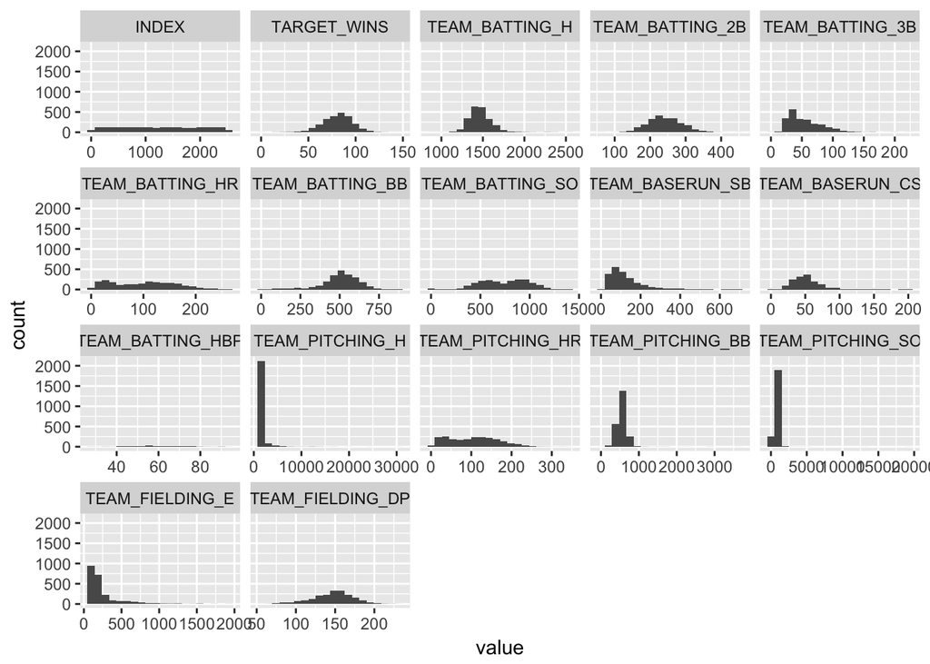

```r
ggtrain = reshape2::melt(train)
ggplot(ggtrain, aes(value)) + facet_wrap(~variable, scales = "free_x") + geom_histogram(bins = 20)
```

We will see the linearity between Dependent Variable and Independent Variables. For us the dependent variable is TARGET_WIN and independent variable are rest. For KDEPAIRS, excluded variables which contained NA values

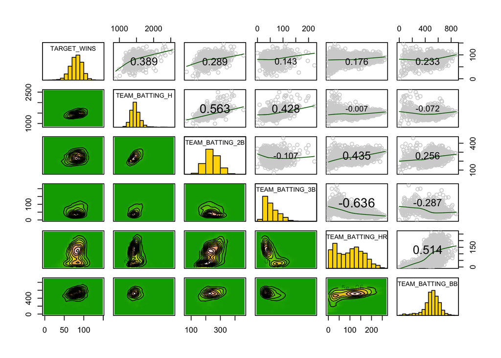

```r
battingdata = train[c("TARGET_WINS", "TEAM_BATTING_H", "TEAM_BATTING_2B", "TEAM_BATTING_3B",
    "TEAM_BATTING_HR", "TEAM_BATTING_BB")]
pitchingdata = train[c("TARGET_WINS", "TEAM_PITCHING_H", "TEAM_PITCHING_HR",
    "TEAM_PITCHING_BB")]
fieldingdata = train[c("TARGET_WINS", "TEAM_FIELDING_E")]

kdepairs(battingdata)
```

KDEPAIRS for Pitching Data Variables and TARGET_WINS

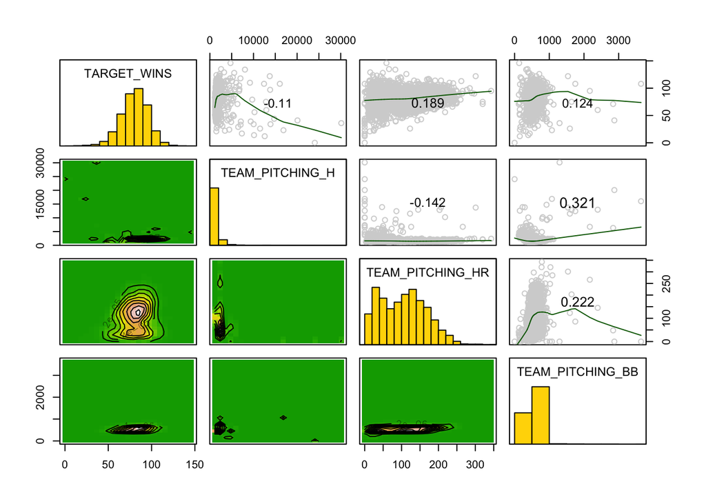

```r
kdepairs(pitchingdata)
```

KDEPAIRS for Fielding Data Variables and TARGET_WINS

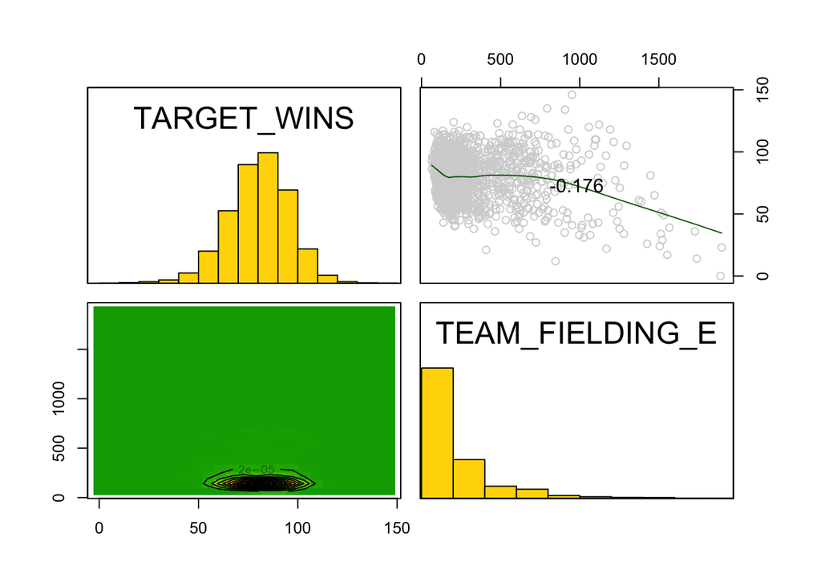

```r
kdepairs(fieldingdata)
```

## 2.DATA PREPARATION

Removal of NAs

```r
mean_CS = round(mean(train$TEAM_BASERUN_CS, na.rm = T))
mean_SB = round(mean(train$TEAM_BASERUN_SB, na.rm = T))
mean_DP = round(mean(train$TEAM_FIELDING_DP, na.rm = T))
mean_BAT_SO = round(mean(train$TEAM_BATTING_SO, na.rm = T))
mean_PIT_SO = round(mean(train$TEAM_PITCHING_SO, na.rm = T))

train$TEAM_BASERUN_CS[is.na(train$TEAM_BASERUN_CS)] = mean_CS
train$TEAM_BASERUN_SB[is.na(train$TEAM_BASERUN_SB)] = mean_SB
train$TEAM_FIELDING_DP[is.na(train$TEAM_FIELDING_DP)] = mean_DP
train$TEAM_BATTING_SO[is.na(train$TEAM_BATTING_SO)] = mean_BAT_SO
train$TEAM_PITCHING_SO[is.na(train$TEAM_PITCHING_SO)] = mean_PIT_SO

summary(train)
```

```
##      INDEX         TARGET_WINS     TEAM_BATTING_H TEAM_BATTING_2B
##  Min.   :   1.0   Min.   :  0.00   Min.   : 891   Min.   : 69.0
##  1st Qu.: 630.8   1st Qu.: 71.00   1st Qu.:1383   1st Qu.:208.0
##  Median :1270.5   Median : 82.00   Median :1454   Median :238.0
##  Mean   :1268.5   Mean   : 80.79   Mean   :1469   Mean   :241.2
##  3rd Qu.:1915.5   3rd Qu.: 92.00   3rd Qu.:1537   3rd Qu.:273.0
##  Max.   :2535.0   Max.   :146.00   Max.   :2554   Max.   :458.0
##
##  TEAM_BATTING_3B  TEAM_BATTING_HR  TEAM_BATTING_BB TEAM_BATTING_SO
##  Min.   :  0.00   Min.   :  0.00   Min.   :  0.0   Min.   :   0.0
##  1st Qu.: 34.00   1st Qu.: 42.00   1st Qu.:451.0   1st Qu.: 556.8
##  Median : 47.00   Median :102.00   Median :512.0   Median : 736.0
##  Mean   : 55.25   Mean   : 99.61   Mean   :501.6   Mean   : 735.6
##  3rd Qu.: 72.00   3rd Qu.:147.00   3rd Qu.:580.0   3rd Qu.: 925.0
##  Max.   :223.00   Max.   :264.00   Max.   :878.0   Max.   :1399.0
##
##  TEAM_BASERUN_SB TEAM_BASERUN_CS  TEAM_BATTING_HBP TEAM_PITCHING_H
##  Min.   :  0.0   Min.   :  0.00   Min.   :29.00    Min.   : 1137
##  1st Qu.: 67.0   1st Qu.: 44.00   1st Qu.:50.50    1st Qu.: 1419
##  Median :106.0   Median : 53.00   Median :58.00    Median : 1518
##  Mean   :124.8   Mean   : 52.87   Mean   :59.36    Mean   : 1779
##  3rd Qu.:151.0   3rd Qu.: 54.25   3rd Qu.:67.00    3rd Qu.: 1682
##  Max.   :697.0   Max.   :201.00   Max.   :95.00    Max.   :30132
##                                   NA's   :2085
##  TEAM_PITCHING_HR TEAM_PITCHING_BB TEAM_PITCHING_SO  TEAM_FIELDING_E
##  Min.   :  0.0    Min.   :   0.0   Min.   :    0.0   Min.   :  65.0
##  1st Qu.: 50.0    1st Qu.: 476.0   1st Qu.:  626.0   1st Qu.: 127.0
##  Median :107.0    Median : 536.5   Median :  818.0   Median : 159.0
##  Mean   :105.7    Mean   : 553.0   Mean   :  817.7   Mean   : 246.5
##  3rd Qu.:150.0    3rd Qu.: 611.0   3rd Qu.:  957.0   3rd Qu.: 249.2
##  Max.   :343.0    Max.   :3645.0   Max.   :19278.0   Max.   :1898.0
##
##  TEAM_FIELDING_DP
##  Min.   : 52.0
##  1st Qu.:134.0
##  Median :146.0
##  Mean   :146.3
##  3rd Qu.:161.2
##  Max.   :228.0
##
```

But for TEAM_BATTING_HBP rest of the field does not contain NA values. We would like to see the Histogram again after filling NAs will substitutes.

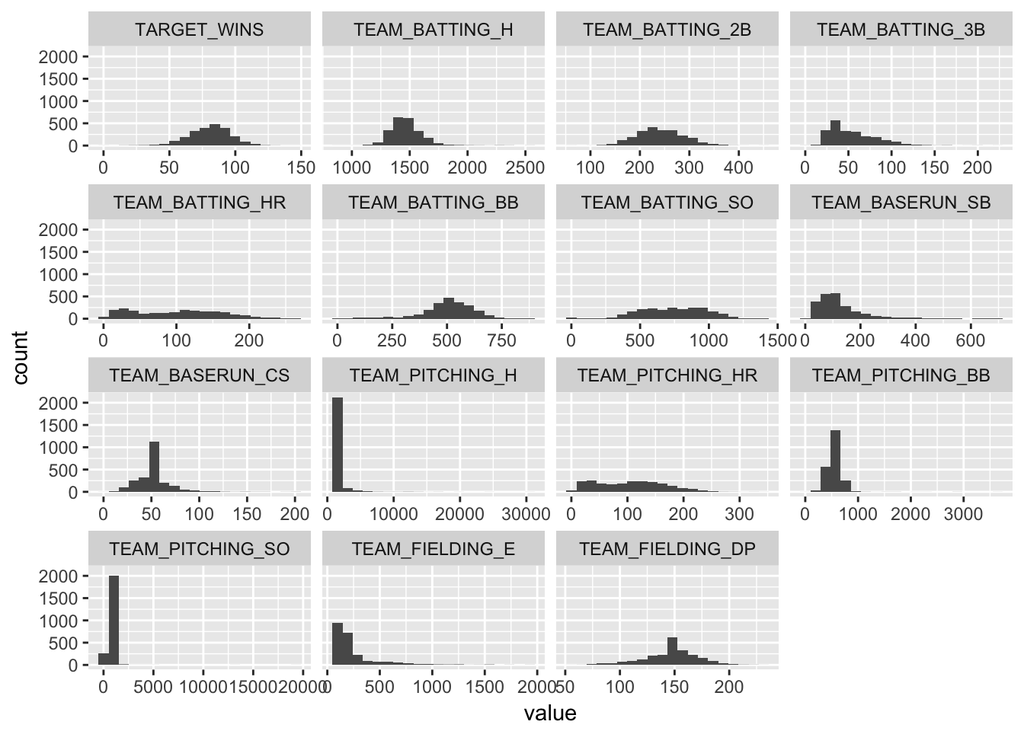

```r
newtrain = subset(train, select = -c(INDEX, TEAM_BATTING_HBP))
ggtrain = reshape2::melt(newtrain)
ggplot(ggtrain, aes(value)) + facet_wrap(~variable, scales = "free_x") + geom_histogram(bins = 20)
```

## Correlation between Independent Variables.

We will see the linearity between Independent Variables, excluding Dependent Variable TARGET_WINS and other variables which has NA Values.

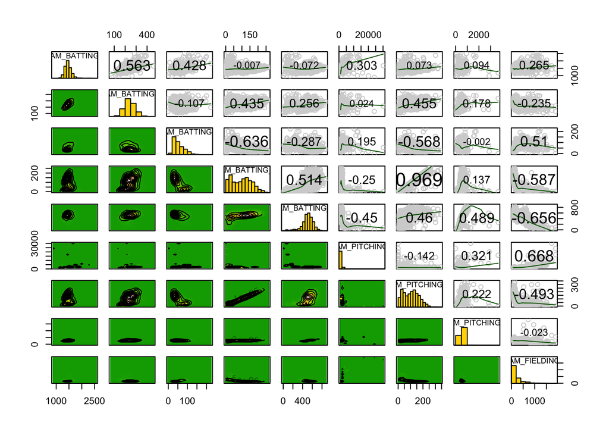

```r
IndData = train[c("TEAM_BATTING_H", "TEAM_BATTING_2B", "TEAM_BATTING_3B", "TEAM_BATTING_HR",
    "TEAM_BATTING_BB", "TEAM_PITCHING_H", "TEAM_PITCHING_HR", "TEAM_PITCHING_BB",
    "TEAM_FIELDING_E")]

kdepairs(IndData)
```

From the above plot we can see the following strong correlation betweem some of Independent Variables. We will perform a Corr Plot between the Independent variables, which will give us more insight This is need to check Multicollinearity between independent variables.

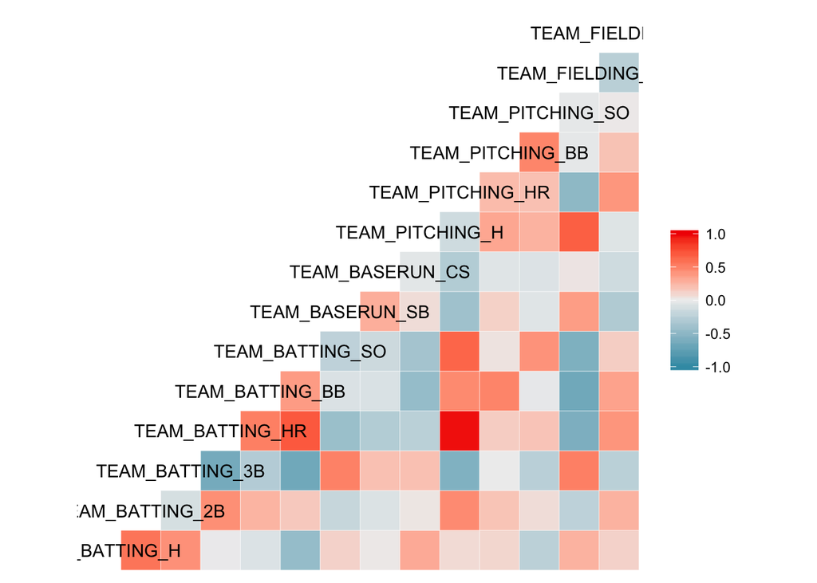

```r
multicol = subset(train, select = -c(INDEX, TARGET_WINS, TEAM_BATTING_HBP))
ggcorr(multicol)
```

## 3. BUILD MODELS

### Model 1 : For first we will create a model with TARGET_WINS and all other independent variables we are interested with.

```r
## Raw data, all variables included in the model
train = subset(train, select = -c(INDEX))
model1 = lm(TARGET_WINS ~ ., data = train)
summary(model1)
```

```
##
## Call:
## lm(formula = TARGET_WINS ~ ., data = train)
##
## Residuals:
##      Min       1Q   Median       3Q      Max
## -19.8708  -5.6564  -0.0599   5.2545  22.9274
##
## Coefficients:
##                  Estimate Std. Error t value Pr(>|t|)
## (Intercept)      60.28826   19.67842   3.064  0.00253 **
## TEAM_BATTING_H    1.91348    2.76139   0.693  0.48927
## TEAM_BATTING_2B   0.02639    0.03029   0.871  0.38484
## TEAM_BATTING_3B  -0.10118    0.07751  -1.305  0.19348
## TEAM_BATTING_HR  -4.84371   10.50851  -0.461  0.64542
## TEAM_BATTING_BB  -4.45969    3.63624  -1.226  0.22167
## TEAM_BATTING_SO   0.34196    2.59876   0.132  0.89546
## TEAM_BASERUN_SB   0.03304    0.02867   1.152  0.25071
## TEAM_BASERUN_CS  -0.01104    0.07143  -0.155  0.87730
## TEAM_BATTING_HBP  0.08247    0.04960   1.663  0.09815 .
## TEAM_PITCHING_H  -1.89096    2.76095  -0.685  0.49432
## TEAM_PITCHING_HR  4.93043   10.50664   0.469  0.63946
## TEAM_PITCHING_BB  4.51089    3.63372   1.241  0.21612
## TEAM_PITCHING_SO -0.37364    2.59705  -0.144  0.88577
## TEAM_FIELDING_E  -0.17204    0.04140  -4.155 5.08e-05 ***
## TEAM_FIELDING_DP -0.10819    0.03654  -2.961  0.00349 **
## ---
## Signif. codes:  0 '***' 0.001 '**' 0.01 '*' 0.05 '.' 0.1 ' ' 1
##
## Residual standard error: 8.467 on 175 degrees of freedom
##   (2085 observations deleted due to missingness)
## Multiple R-squared:  0.5501, Adjusted R-squared:  0.5116
## F-statistic: 14.27 on 15 and 175 DF,  p-value: < 2.2e-16
```

From the first Model we can see that most of the independent variables have a higher p-value but for TEAM_FIELDING_DP and TEAM_FIELDING_E. We are not taking TEAM_BATTING_HBP this in to consideration, because we will dropping this from our model because of NA values. The R^2 and Adjusted R^2 are at 55% and 50% respectively. This model defenitely needs some tunning.

### For Model 2 : We would like to do some back ward elimination and see whether there is some scope of improvement.

We will drop the following from train data

```r
train2 = subset(train, select = -c(TEAM_BATTING_HBP))

model2 = lm(TARGET_WINS ~ ., data = train2)
summary(model2)
```

```
##
## Call:
## lm(formula = TARGET_WINS ~ ., data = train2)
##
## Residuals:
##     Min      1Q  Median      3Q     Max
## -50.027  -8.575   0.137   8.342  58.611
##
## Coefficients:
##                    Estimate Std. Error t value Pr(>|t|)
## (Intercept)       2.507e+01  5.399e+00   4.643 3.63e-06 ***
## TEAM_BATTING_H    4.824e-02  3.687e-03  13.084  < 2e-16 ***
## TEAM_BATTING_2B  -2.004e-02  9.151e-03  -2.190 0.028604 *
## TEAM_BATTING_3B   6.040e-02  1.676e-02   3.604 0.000320 ***
## TEAM_BATTING_HR   5.298e-02  2.743e-02   1.931 0.053548 .
## TEAM_BATTING_BB   1.041e-02  5.818e-03   1.789 0.073671 .
## TEAM_BATTING_SO  -9.351e-03  2.550e-03  -3.667 0.000251 ***
## TEAM_BASERUN_SB   2.946e-02  4.464e-03   6.600 5.12e-11 ***
## TEAM_BASERUN_CS  -1.173e-02  1.616e-02  -0.726 0.467830
## TEAM_PITCHING_H  -7.315e-04  3.676e-04  -1.990 0.046736 *
## TEAM_PITCHING_HR  1.481e-02  2.432e-02   0.609 0.542633
## TEAM_PITCHING_BB  8.066e-05  4.145e-03   0.019 0.984477
## TEAM_PITCHING_SO  2.841e-03  9.187e-04   3.092 0.002009 **
## TEAM_FIELDING_E  -2.118e-02  2.480e-03  -8.542  < 2e-16 ***
## TEAM_FIELDING_DP -1.212e-01  1.304e-02  -9.298  < 2e-16 ***
## ---
## Signif. codes:  0 '***' 0.001 '**' 0.01 '*' 0.05 '.' 0.1 ' ' 1
##
## Residual standard error: 13.04 on 2261 degrees of freedom
## Multiple R-squared:  0.319,  Adjusted R-squared:  0.3148
## F-statistic: 75.65 on 14 and 2261 DF,  p-value: < 2.2e-16
```

### For Model 3 : From Training Data Set 2, we will remove the following variables, which has relatively higher p-values.

TEAM_PITCHING_BB(Highest p-value) TEAM_BASERUN_CS(High P-value) TEAM_PITCHING_HR(Strong correlation with another variable)

```r
train3 = subset(train2, select = -c(TEAM_PITCHING_BB, TEAM_PITCHING_HR, TEAM_BASERUN_CS))

model3 = lm(TARGET_WINS ~ ., data = train3)
summary(model3)
```

```
##
## Call:
## lm(formula = TARGET_WINS ~ ., data = train3)
##
## Residuals:
##     Min      1Q  Median      3Q     Max
## -49.933  -8.565   0.093   8.392  58.634
##
## Coefficients:
##                    Estimate Std. Error t value Pr(>|t|)
## (Intercept)      23.7228255  5.2236488   4.541 5.88e-06 ***
## TEAM_BATTING_H    0.0484514  0.0036619  13.231  < 2e-16 ***
## TEAM_BATTING_2B  -0.0204939  0.0091353  -2.243 0.024969 *
## TEAM_BATTING_3B   0.0623760  0.0165840   3.761 0.000173 ***
## TEAM_BATTING_HR   0.0697597  0.0096249   7.248 5.78e-13 ***
## TEAM_BATTING_BB   0.0107278  0.0033484   3.204 0.001375 **
## TEAM_BATTING_SO  -0.0093020  0.0024567  -3.786 0.000157 ***
## TEAM_BASERUN_SB   0.0287487  0.0042919   6.698 2.65e-11 ***
## TEAM_PITCHING_H  -0.0006894  0.0003211  -2.147 0.031893 *
## TEAM_PITCHING_SO  0.0028828  0.0006707   4.298 1.79e-05 ***
## TEAM_FIELDING_E  -0.0206650  0.0024120  -8.568  < 2e-16 ***
## TEAM_FIELDING_DP -0.1211806  0.0130256  -9.303  < 2e-16 ***
## ---
## Signif. codes:  0 '***' 0.001 '**' 0.01 '*' 0.05 '.' 0.1 ' ' 1
##
## Residual standard error: 13.03 on 2264 degrees of freedom
## Multiple R-squared:  0.3187, Adjusted R-squared:  0.3154
## F-statistic: 96.27 on 11 and 2264 DF,  p-value: < 2.2e-16
```

### For Model 4, We are going to do a Step for our first training model and see what are the variables that are being dropped.

```r
model1 = lm(TARGET_WINS ~ ., data = train)
selectedMod = step(model1)
```

```
## Start:  AIC=831.31
## TARGET_WINS ~ TEAM_BATTING_H + TEAM_BATTING_2B + TEAM_BATTING_3B +
##     TEAM_BATTING_HR + TEAM_BATTING_BB + TEAM_BATTING_SO + TEAM_BASERUN_SB +
##     TEAM_BASERUN_CS + TEAM_BATTING_HBP + TEAM_PITCHING_H + TEAM_PITCHING_HR +
##     TEAM_PITCHING_BB + TEAM_PITCHING_SO + TEAM_FIELDING_E + TEAM_FIELDING_DP
##
##                    Df Sum of Sq   RSS    AIC
## - TEAM_BATTING_SO   1      1.24 12547 829.33
## - TEAM_PITCHING_SO  1      1.48 12547 829.33
## - TEAM_BASERUN_CS   1      1.71 12548 829.34
## - TEAM_BATTING_HR   1     15.23 12561 829.54
## - TEAM_PITCHING_HR  1     15.79 12562 829.55
## - TEAM_PITCHING_H   1     33.63 12580 829.82
## - TEAM_BATTING_H    1     34.42 12580 829.83
## - TEAM_BATTING_2B   1     54.41 12600 830.14
## - TEAM_BASERUN_SB   1     95.22 12641 830.76
## - TEAM_BATTING_BB   1    107.84 12654 830.95
## - TEAM_PITCHING_BB  1    110.48 12656 830.99
## - TEAM_BATTING_3B   1    122.16 12668 831.16
## <none>                          12546 831.31
## - TEAM_BATTING_HBP  1    198.21 12744 832.31
## - TEAM_FIELDING_DP  1    628.49 13174 838.65
## - TEAM_FIELDING_E   1   1237.79 13784 847.28
##
## Step:  AIC=829.33
## TARGET_WINS ~ TEAM_BATTING_H + TEAM_BATTING_2B + TEAM_BATTING_3B +
##     TEAM_BATTING_HR + TEAM_BATTING_BB + TEAM_BASERUN_SB + TEAM_BASERUN_CS +
##     TEAM_BATTING_HBP + TEAM_PITCHING_H + TEAM_PITCHING_HR + TEAM_PITCHING_BB +
##     TEAM_PITCHING_SO + TEAM_FIELDING_E + TEAM_FIELDING_DP
##
##                    Df Sum of Sq   RSS    AIC
## - TEAM_BASERUN_CS   1      1.59 12549 827.35
## - TEAM_BATTING_HR   1     15.82 12563 827.57
## - TEAM_PITCHING_HR  1     16.39 12564 827.58
## - TEAM_BATTING_2B   1     53.47 12601 828.14
## - TEAM_PITCHING_H   1     88.45 12636 828.67
## - TEAM_BATTING_H    1     90.30 12637 828.70
## - TEAM_BASERUN_SB   1     94.19 12641 828.76
## - TEAM_BATTING_BB   1    107.95 12655 828.97
## - TEAM_PITCHING_BB  1    110.60 12658 829.01
```

[output cut: 118 more lines]

```
## - TEAM_PITCHING_BB  1   2371.12 15219 852.20
##
## Step:  AIC=821.82
## TARGET_WINS ~ TEAM_BATTING_H + TEAM_BATTING_HBP + TEAM_PITCHING_HR +
##     TEAM_PITCHING_BB + TEAM_PITCHING_SO + TEAM_FIELDING_E + TEAM_FIELDING_DP
##
##                    Df Sum of Sq   RSS    AIC
## <none>                          12981 821.82
## - TEAM_BATTING_HBP  1    228.70 13210 823.16
## - TEAM_BATTING_H    1    449.87 13431 826.33
## - TEAM_FIELDING_DP  1    813.17 13794 831.43
## - TEAM_PITCHING_HR  1    990.20 13971 833.86
## - TEAM_PITCHING_SO  1   1316.56 14298 838.27
## - TEAM_FIELDING_E   1   1334.60 14316 838.52
## - TEAM_PITCHING_BB  1   2583.00 15564 854.49
```

```r
summary(selectedMod)
```

```
##
## Call:
## lm(formula = TARGET_WINS ~ TEAM_BATTING_H + TEAM_BATTING_HBP +
##     TEAM_PITCHING_HR + TEAM_PITCHING_BB + TEAM_PITCHING_SO +
##     TEAM_FIELDING_E + TEAM_FIELDING_DP, data = train)
##
## Residuals:
##      Min       1Q   Median       3Q      Max
## -20.2248  -5.6294  -0.0212   5.0439  21.3065
##
## Coefficients:
##                  Estimate Std. Error t value Pr(>|t|)
## (Intercept)      60.95454   19.10292   3.191 0.001670 **
## TEAM_BATTING_H    0.02541    0.01009   2.518 0.012648 *
## TEAM_BATTING_HBP  0.08712    0.04852   1.796 0.074211 .
## TEAM_PITCHING_HR  0.08945    0.02394   3.736 0.000249 ***
## TEAM_PITCHING_BB  0.05672    0.00940   6.034 8.66e-09 ***
## TEAM_PITCHING_SO -0.03136    0.00728  -4.308 2.68e-05 ***
## TEAM_FIELDING_E  -0.17218    0.03970  -4.338 2.38e-05 ***
## TEAM_FIELDING_DP -0.11904    0.03516  -3.386 0.000869 ***
## ---
## Signif. codes:  0 '***' 0.001 '**' 0.01 '*' 0.05 '.' 0.1 ' ' 1
##
## Residual standard error: 8.422 on 183 degrees of freedom
##   (2085 observations deleted due to missingness)
## Multiple R-squared:  0.5345, Adjusted R-squared:  0.5167
## F-statistic: 30.02 on 7 and 183 DF,  p-value: < 2.2e-16
```

## 4 . SELECT MODELS

Now we have four models to select our model. We will see all the important statistics of the models and compare.

```r
results = NULL
modellist = list(m1 = model1, m2 = model2, m3 = model3, m4 = selectedMod)

for (i in names(modellist)) {
    s = summary(modellist[[i]])
    name = i
    mse <- mean(s$residuals^2)
    r2 <- s$r.squared
    f <- s$fstatistic[1]
    k <- s$fstatistic[2]
    n <- s$fstatistic[3]
    results = rbind(results, data.frame(name = name, rsquared = r2, mse = mse,
        f = f, k = k, n = n))
}
rownames(results) = NULL
results
```

```
##   name  rsquared       mse        f  k    n
## 1   m1 0.5501165  65.68529 14.26597 15  175
## 2   m2 0.3189830 168.90672 75.64533 14 2261
## 3   m3 0.3186760 168.98287 96.26742 11 2264
## 4   m4 0.5345121  67.96361 30.01941  7  183
```

Out of 4 models, we will go with Model 4(M4) as our model and we see how the QQ Plots of Residuals looks like.

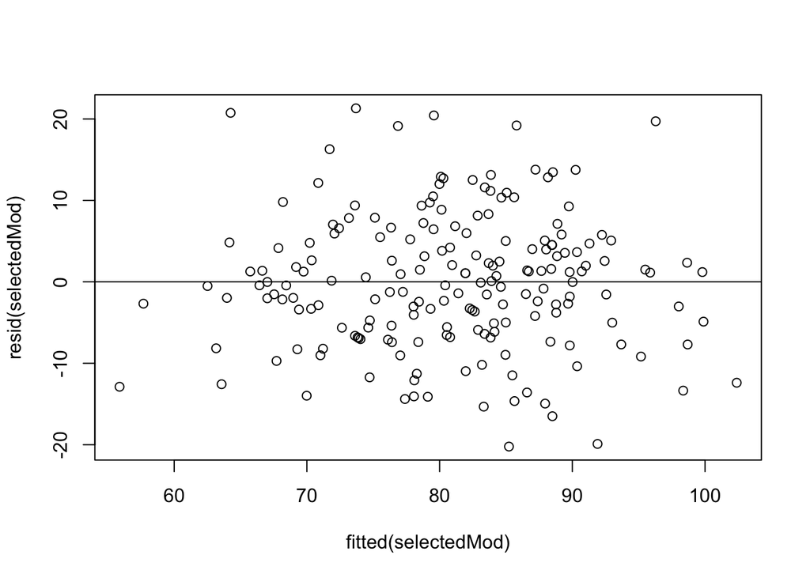

```r
plot(fitted(selectedMod), resid(selectedMod))
abline(h = 0)
```

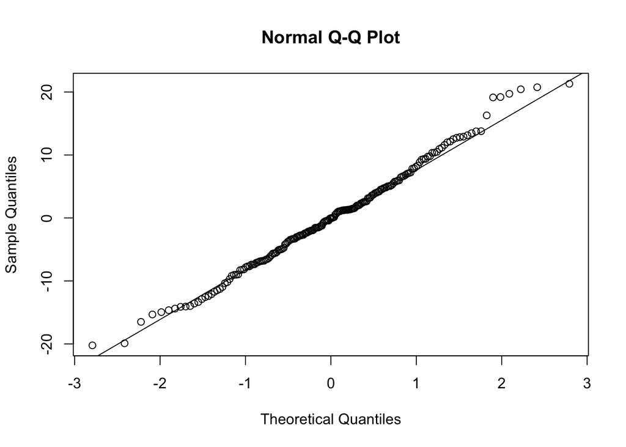

```r
qqnorm(selectedMod$residuals)
qqline(selectedMod$residuals)
```

Residuals are almost normally distributed except for the at the top of the QQline where points are little displaced from the line.

Since most of the values from our prediction are NA values, we have replaced those with mean of training data set.

```r
outprediction = predict(selectedMod, newdata = test, type = "response")
outprediction[is.na(outprediction)] = mean(train$TARGET_WINS)
```

## References:

http://r-statistics.co/Linear-Regression.html

http://r-statistics.co/Model-Selection-in-R.html